# total_project_17_04_20

### 3.3 NN on k-means clustering HOG feature augmented decomposed data

```python
#### neural network model architecture
import numpy as np
import tensorflow.keras
from tensorflow.keras.models import Sequential
from tensorflow.keras.layers import Dense, Dropout, Activation
from tensorflow.keras.callbacks import EarlyStopping
from tensorflow.keras.optimizers import SGD # stochastic gradient descent

model = Sequential()
model.add(Dense(64, activation='tanh'))
model.add(Dropout(0.5)) # learning rate drop
model.add(Dense(128, activation='tanh')) # new layer after 1st time
model.add(Dropout(0.5))
model.add(Dense(128, activation='tanh')) # new layer after 1st time
model.add(Dropout(0.5))
model.add(Dense(decHOGrepo_ros.shape[0], activation='softmax'))
sgd = SGD(lr=0.01, decay=1e-4, momentum=0.9, nesterov=True) # decay from -6 to -4 4th time
```

```python
model.compile(loss='sparse_categorical_crossentropy',
             optimizer= sgd,
             metrics=['accuracy'])
```

```python
#### NN training
historydecHOG = model.fit(decHOGX_train, decHOGy_train, validation_data=(decHOGX_test, decHOGy_test), epochs=200)

score = model.evaluate(decHOGX_test, decHOGy_test)
print("model score: ", score)
```

```
Train on 3266 samples, validate on 1089 samples
model score:  [0.16033185578090117, 0.97979796]
```

```
[0.16033185578090117, 0.97979796]

loss:  0.25

accuracy:  0.94

val_loss:  0.25

val_acc:  0.95
```

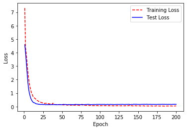

```python
#### NN metrics on Hog
score = model.evaluate(decHOGX_test, decHOGy_test)
print(score)
print()

training_loss = historydecHOG.history['loss']
print('loss: ', round(np.mean(training_loss),2))
print()

training_acc = historydecHOG.history['accuracy']
print('accuracy: ', round(np.mean(training_acc),2))
print()

test_loss = historydecHOG.history['val_loss']
print('val_loss: ', round(np.mean(test_loss),2))
print()

test_acc = historydecHOG.history['val_accuracy']
print('val_acc: ',round(np.mean(test_acc),2))
print()
print()
# Create count of the number of epochs
epoch_count = range(1, len(training_loss) + 1)

# Visualize loss history
plt.plot(epoch_count, training_loss, 'r--')
plt.plot(epoch_count, test_loss, 'b-')
plt.legend(['Training Loss', 'Test Loss'])
plt.xlabel('Epoch')
plt.ylabel('Loss')
plt.show()
```

The results we are getting regarding the loss are excellent for both training and test set. Loss basically seems to nullify right afte the first 20 epochs for both training and test set. The slight lower loss in the beginning of the graph for the test set may be due to the fact that validation loss is calculated after each epoch is finished, while training loss is calculated during the epoch. So if we were to be more accurate the test loss should be moved half an epoch to the right.

```python
#### Metrics on HOG augmented data test set
decHOGy_pred1 = model.predict(decHOGX_test,verbose=0, steps=None)
decHOGy_pred = np.argmax(decHOGy_pred1, axis=1)

decHOGNNaccuracy = accuracy_score(decHOGy_test, decHOGy_pred)
print("NN accuracy: ", round(decHOGNNaccuracy,3))

decHOGNNrecall = recall_score(decHOGy_test, decHOGy_pred , average="macro")
print("NN recall: ", round(decHOGNNrecall,3))

decHOGNNprecision = precision_score(decHOGy_test, decHOGy_pred , average="macro")
print("NN precision: ", round(decHOGNNprecision,3))

decHOGNNF1_score = f1_score(decHOGy_test, decHOGy_pred , average="macro")
print("NN F1-score: ", round(decHOGNNF1_score,3))


decHOGNNkapa = cohen_kappa_score(decHOGy_test, decHOGy_pred)
print('kappa-score: ', round(decHOGNNkapa, 3))

decHOGNNMCC = matthews_corrcoef(decHOGy_test, decHOGy_pred)
print('MCC: ', round(decHOGNNMCC,3))

print('Test loss:', round(score[0], 2))
```

```
NN accuracy:  0.98
NN recall:  0.98
NN precision:  0.981
NN F1-score:  0.979
kappa-score:  0.979
MCC:  0.98
Test loss: 0.16
```

### 3.4 NN on agglomerative clustering HOG feature augmented decomposed data

```python
#### neural network model architecture
import numpy as np
import tensorflow.keras
from tensorflow.keras.models import Sequential
from tensorflow.keras.layers import Dense, Dropout, Activation
from tensorflow.keras.callbacks import EarlyStopping
from tensorflow.keras.optimizers import SGD # stochastic gradient descent

model = Sequential()
model.add(Dense(64, activation='tanh'))
model.add(Dropout(0.5)) # learning rate drop
model.add(Dense(128, activation='tanh')) # new layer after 1st time
model.add(Dropout(0.5))
model.add(Dense(128, activation='tanh')) # new layer after 1st time
model.add(Dropout(0.5))
model.add(Dense(decHOGtarget_ros.shape[0], activation='softmax'))
sgd = SGD(lr=0.01, decay=1e-4, momentum=0.9, nesterov=True) # decay from -6 to -4 4th time
```

```python
model.compile(loss='sparse_categorical_crossentropy',
             optimizer= sgd,
             metrics=['accuracy'])
```

```python
#### NN training
AGGhistory = model.fit(decAGGHOGX_train, decAGGHOGy_train, validation_data=(decAGGHOGX_test, decAGGHOGy_test), epochs=200)

score = model.evaluate(decAGGHOGX_test, decAGGHOGy_test)
print("model score: ", score)
```

```
[0.0689298615036717, 0.9875877]

loss:  0.49

accuracy:  0.88

val_loss:  0.26

val_acc:  0.95
```

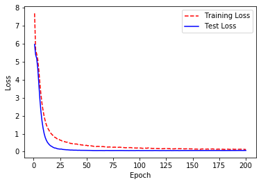

```python
#### NN metrics on Hog
score = model.evaluate(decAGGHOGX_test, decAGGHOGy_test)
print(score)
print()

training_loss = AGGhistory.history['loss']
print('loss: ', round(np.mean(training_loss),2))
print()

training_acc = AGGhistory.history['accuracy']
print('accuracy: ', round(np.mean(training_acc),2))
print()

test_loss = AGGhistory.history['val_loss']
print('val_loss: ', round(np.mean(test_loss),2))
print()

test_acc = AGGhistory.history['val_accuracy']
print('val_acc: ',round(np.mean(test_acc),2))
print()
print()
# Create count of the number of epochs
epoch_count = range(1, len(training_loss) + 1)

# Visualize loss history
plt.plot(epoch_count, training_loss, 'r--')
plt.plot(epoch_count, test_loss, 'b-')
plt.legend(['Training Loss', 'Test Loss'])
plt.xlabel('Epoch')
plt.ylabel('Loss')
plt.show()
```

```python
#### Metrics on HOG augmented data test set
decAGGHOGy_pred1 = model.predict(decAGGHOGX_test,verbose=0, steps=None)
decAGGHOGy_pred = np.argmax(decAGGHOGy_pred1, axis=1)

decAGGHOGNNaccuracy = accuracy_score(decAGGHOGy_test, decAGGHOGy_pred)
print("NN accuracy: ", round(decAGGHOGNNaccuracy,3))

decAGGHOGNNrecall = recall_score(decAGGHOGy_test, decAGGHOGy_pred , average="macro")
print("NN recall: ", round(decAGGHOGNNrecall,3))

decAGGHOGNNprecision = precision_score(decAGGHOGy_test, decAGGHOGy_pred , average="macro")
print("NN precision: ", round(decAGGHOGNNprecision,3))

decAGGHOGNNF1_score = f1_score(decAGGHOGy_test, decAGGHOGy_pred , average="macro")
print("NN F1-score: ", round(decAGGHOGNNF1_score,3))


decAGGHOGNNkapa = cohen_kappa_score(decAGGHOGy_test, decAGGHOGy_pred)
print('kappa-score: ', round(decAGGHOGNNkapa, 3))

decAGGHOGNNMCC = matthews_corrcoef(decAGGHOGy_test, decAGGHOGy_pred)
print('MCC: ', round(decAGGHOGNNMCC,3))

print('Test loss:', round(score[0], 2))
```

```
NN accuracy:  0.988
NN recall:  0.987
NN precision:  0.989
NN F1-score:  0.987
kappa-score:  0.988
MCC:  0.988
Test loss: 0.07
```

### 3.3 NN on k-means clustering PCA feature augmented decomposed data

```python
#### neural network model architecture
import numpy as np
import tensorflow.keras
from tensorflow.keras.models import Sequential
from tensorflow.keras.layers import Dense, Dropout, Activation
from tensorflow.keras.callbacks import EarlyStopping
from tensorflow.keras.optimizers import SGD # stochastic gradient descent

model = Sequential()
model.add(Dense(64, activation='tanh'))
model.add(Dropout(0.5)) # learning rate drop
model.add(Dense(128, activation='tanh')) # new layer after 1st time
model.add(Dropout(0.5))
model.add(Dense(128, activation='tanh')) # new layer after 1st time
model.add(Dropout(0.5))
model.add(Dense(decPCAtarget_ros.shape[0], activation='softmax'))
sgd = SGD(lr=0.01, decay=1e-4, momentum=0.9, nesterov=True) # decay from -6 to -4 4th time
```

```python
model.compile(loss='sparse_categorical_crossentropy',
             optimizer= sgd,
             metrics=['accuracy'])
```

```python
#### NN training
decPCA_history = model.fit(decPCAX_train, decPCAy_train, validation_data=(decPCAX_test, decPCAy_test), epochs=200)

score = model.evaluate(decPCAX_test, decPCAy_test)
print("model score: ", score)
```

```
[1.8488042613690705, 0.43723673]

loss:  2.73

accuracy:  0.23

val_loss:  2.3

val_acc:  0.34
```

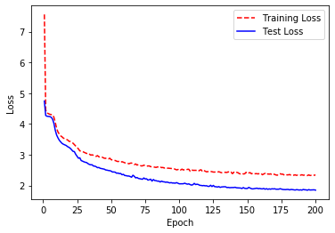

```python
#### NN metrics on PCA kmeans augmented data
score = model.evaluate(decPCAX_test, decPCAy_test)
print(score)
print()

training_loss = decPCA_history.history['loss']
print('loss: ', round(np.mean(training_loss),2))
print()

training_acc = decPCA_history.history['accuracy']
print('accuracy: ', round(np.mean(training_acc),2))
print()

test_loss = decPCA_history.history['val_loss']
print('val_loss: ', round(np.mean(test_loss),2))
print()

test_acc = decPCA_history.history['val_accuracy']
print('val_acc: ',round(np.mean(test_acc),2))
print()
print()
# Create count of the number of epochs
epoch_count = range(1, len(training_loss) + 1)

# Visualize loss history
plt.plot(epoch_count, training_loss, 'r--')
plt.plot(epoch_count, test_loss, 'b-')
plt.legend(['Training Loss', 'Test Loss'])
plt.xlabel('Epoch')
plt.ylabel('Loss')
plt.show()
```

```python
#### Metrics on PCA kmeans decomposed augmented data test set
decPCAy_pred1 = model.predict(decPCAX_test,verbose=0, steps=None)
decPCAy_pred = np.argmax(decPCAy_pred1, axis=1)

decPCANNaccuracy = accuracy_score(decPCAy_test, decPCAy_pred)
print("NN accuracy: ", round(decPCANNaccuracy,3))

decPCANNrecall = recall_score(decPCAy_test, decPCAy_pred , average="macro")
print("NN recall: ", round(decPCANNrecall,3))

decPCANNprecision = precision_score(decPCAy_test, decPCAy_pred , average="macro", zero_division=1)
print("NN precision: ", round(decPCANNprecision,3))

decPCANNF1_score = f1_score(decPCAy_test, decPCAy_pred , average="macro")
print("NN F1-score: ", round(decPCANNF1_score,3))


decPCANNkapa = cohen_kappa_score(decPCAy_test, decPCAy_pred)
print('kappa-score: ', round(decPCANNkapa, 3))

decPCANNMCC = matthews_corrcoef(decPCAy_test, decPCAy_pred)
print('MCC: ', round(decPCANNMCC,3))

print('Test loss:', round(score[0], 2))
```

```
NN accuracy:  0.437
NN recall:  0.438
NN precision:  0.553
NN F1-score:  0.371
kappa-score:  0.428
MCC:  0.431
Test loss: 1.85
```

### 3.4 NN on agglomerative clustering PCA feature augmented decomposed data

```python
#### neural network model architecture
import numpy as np
import tensorflow.keras
from tensorflow.keras.models import Sequential
from tensorflow.keras.layers import Dense, Dropout, Activation
from tensorflow.keras.callbacks import EarlyStopping
from tensorflow.keras.optimizers import SGD # stochastic gradient descent

model = Sequential()
model.add(Dense(64, activation='tanh'))
model.add(Dropout(0.5)) # learning rate drop
model.add(Dense(128, activation='tanh')) # new layer after 1st time
model.add(Dropout(0.5))
model.add(Dense(128, activation='tanh')) # new layer after 1st time
model.add(Dropout(0.5))
model.add(Dense(AGCdecPCAtarget_ros.shape[0], activation='softmax'))
sgd = SGD(lr=0.01, decay=1e-4, momentum=0.9, nesterov=True) # decay from -6 to -4 4th time
```

```python
model.compile(loss='sparse_categorical_crossentropy',
             optimizer= sgd,
             metrics=['accuracy'])
```

```python
#### NN training
AGGdecPCA_history = model.fit(PCAdecAGGX_train, PCAdecAGGy_train, validation_data=(PCAdecAGGX_test,PCAdecAGGy_test), epochs=200)

score = model.evaluate(PCAdecAGGX_test, PCAdecAGGy_test)
print("model score: ", score)
```

```
[1.659473404313764, 0.49273503]

loss:  2.78

accuracy:  0.21

val_loss:  2.3

val_acc:  0.37
```

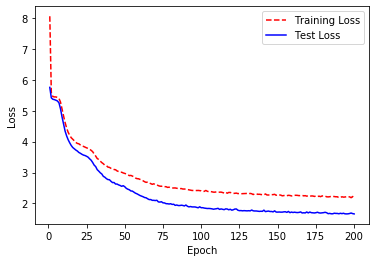

```python
#### NN metrics
score = model.evaluate(PCAdecAGGX_test, PCAdecAGGy_test)
print(score)
print()

training_loss = AGGdecPCA_history.history['loss']
print('loss: ', round(np.mean(training_loss),2))
print()

training_acc = AGGdecPCA_history.history['accuracy']
print('accuracy: ', round(np.mean(training_acc),2))
print()

test_loss = AGGdecPCA_history.history['val_loss']
print('val_loss: ', round(np.mean(test_loss),2))
print()

test_acc = AGGdecPCA_history.history['val_accuracy']
print('val_acc: ',round(np.mean(test_acc),2))
print()
print()
# Create count of the number of epochs
epoch_count = range(1, len(training_loss) + 1)

# Visualize loss history
plt.plot(epoch_count, training_loss, 'r--')
plt.plot(epoch_count, test_loss, 'b-')
plt.legend(['Training Loss', 'Test Loss'])
plt.xlabel('Epoch')
plt.ylabel('Loss')
plt.show()
```

```python
#### Metrics on PCA agglomerative clustering augmented decomposed data test set
PCAdecAGGy_pred1 = model.predict(PCAdecAGGX_test,verbose=0, steps=None)
PCAdecAGGy_pred = np.argmax(PCAdecAGGy_pred1, axis=1)

AGGdecPCANNaccuracy = accuracy_score(PCAdecAGGy_test, PCAdecAGGy_pred)
print("NN accuracy: ", round(AGGdecPCANNaccuracy,3))

AGGdecPCANNrecall = recall_score(PCAdecAGGy_test, PCAdecAGGy_pred , average="macro")
print("NN recall: ", round(AGGdecPCANNrecall,3))

AGGdecPCANNprecision = precision_score(PCAdecAGGy_test, PCAdecAGGy_pred , average="macro", zero_division=1)
print("NN precision: ", round(AGGdecPCANNprecision,3))

AGGdecPCANNF1_score = f1_score(PCAdecAGGy_test, PCAdecAGGy_pred , average="macro")
print("NN F1-score: ", round(AGGdecPCANNF1_score,3))

AGGdecPCANNkapa = cohen_kappa_score(PCAdecAGGy_test, PCAdecAGGy_pred)
print('kappa-score: ', round(AGGdecPCANNkapa, 3))

from sklearn.metrics import matthews_corrcoef
AGGdecPCANNMCC = matthews_corrcoef(PCAdecAGGy_test, PCAdecAGGy_pred)
print('MCC: ', round(AGGdecPCANNMCC,3))

print('Test loss:', round(score[0], 2))
```

```
NN accuracy:  0.493
NN recall:  0.493
NN precision:  0.676
NN F1-score:  0.425
kappa-score:  0.49
MCC:  0.492
Test loss: 1.66
```

## 4. CONVOLUTIONAL NEURAL NETWORKS CLASSIFICATION

### 4.1 CNN on IMAGE AUGMENTED DATASET

```python
#### repository of binarised images and their target
imgD2Copy = imgData2.copy()
```

```python
#### creation of unique indices for targets
import numpy as np
#print(targetBase2)
#T_base = np.asarray(targetBase)
#print(T_base)

tBaseCopy2 = targetBase2.copy()

tBaseCopy2, indices2 = np.unique(tBaseCopy2, return_inverse=True)

# print(tBaseCopy)
#print(tBaseCopy2[indices2])
#print(indices2)
#print(len(indices2))
#print(indices2[2])
#print(indices2[298])

# Create reshaped indices. inds will be the target/class from now on
indicesCP2 = indices2.copy()
print()
#print(indicesCP[0:240])
print()
inds2 =indicesCP2.reshape(-1,1)
#print(inds2[0:240])
```

```python
#### CNN training/test set split
from sklearn.model_selection import train_test_split
np.random.seed(42)
X1_train, X1_test, y1_train, y1_test = train_test_split(imgD2Copy, indices2,
                                                    stratify=indices2,
                                                    test_size=0.25, random_state=40)
```

```python
type(X_train)
X1_train = np.asarray(X1_train)
y1_train = np.asarray(y1_train)
X1_test = np.asarray(X1_test)
y1_test = np.asarray(y1_test)
```

```python
#### reshaping training/test set
X1_train = X1_train.reshape(7296, 100, 100,1)
X1_test = X1_test.reshape(2432, 100, 100,1)
```

```python
#### proof of reshaping
print("X_train shape", X1_train.shape)
print("X_train type", type(X1_train))
print()
print("y_train shape", y1_train.shape)
print("y_train type", type(y1_train))
print()
print("X_test shape", X1_test.shape)
print(type(y1_test))
print()
print("y_test shape", y1_test.shape)
print(type(y1_test))
```

```
X_train shape (7296, 100, 100, 1)
X_train type <class 'numpy.ndarray'>

y_train shape (7296,)
y_train type <class 'numpy.ndarray'>

X_test shape (2432, 100, 100, 1)
<class 'numpy.ndarray'>

y_test shape (2432,)
<class 'numpy.ndarray'>
```

```python
#### Normalize pixel values to be between 0 and 1
train_images, test_images = X1_train / 255.0, X1_test / 255.0
```

```python
from __future__ import absolute_import, division, print_function, unicode_literals
import tensorflow as tf
from tensorflow.keras.layers import Dense, Dropout, Activation
from tensorflow.keras.callbacks import EarlyStopping
from tensorflow.keras import layers, models, optimizers
import matplotlib.pyplot as plt
from tensorflow.keras.optimizers import SGD
from tensorflow.keras.optimizers import Adam
```

```python
#### CNN model architecture
model = models.Sequential()
model.add(layers.Conv2D(32, (3, 3), activation='relu', input_shape=(100, 100, 1)))
model.add(Dropout(0.5))
model.add(layers.MaxPooling2D((2, 2)))
model.add(layers.Conv2D(64, (3, 3), activation='relu'))
model.add(Dropout(0.5))
model.add(layers.MaxPooling2D((2, 2)))
model.add(layers.Conv2D(64, (3, 3), activation='relu'))
model.add(Dropout(0.5))
model.add(layers.Flatten())
model.add(layers.Dense(64, activation='relu'))
model.add(layers.Dense(39))
model.add(Dense(y_train.shape[0], activation='softmax'))
adam = Adam(learning_rate=0.001, beta_1=0.9, beta_2=0.999, amsgrad=False)
```

```python
#### Summarising model
model.summary()
```

```
Model: "sequential_4"
_________________________________________________________________
Layer (type)                 Output Shape              Param #
=================================================================
conv2d_6 (Conv2D)            (None, 98, 98, 32)        320
_________________________________________________________________
dropout_12 (Dropout)         (None, 98, 98, 32)        0
_________________________________________________________________
max_pooling2d_4 (MaxPooling2 (None, 49, 49, 32)        0
_________________________________________________________________
conv2d_7 (Conv2D)            (None, 47, 47, 64)        18496
_________________________________________________________________
dropout_13 (Dropout)         (None, 47, 47, 64)        0
_________________________________________________________________
max_pooling2d_5 (MaxPooling2 (None, 23, 23, 64)        0
_________________________________________________________________
conv2d_8 (Conv2D)            (None, 21, 21, 64)        36928
_________________________________________________________________
dropout_14 (Dropout)         (None, 21, 21, 64)        0
_________________________________________________________________
flatten_2 (Flatten)          (None, 28224)             0
_________________________________________________________________
dense_14 (Dense)             (None, 64)                1806400
_________________________________________________________________
dense_15 (Dense)             (None, 39)                2535
_________________________________________________________________
dense_16 (Dense)             (None, 7296)              291840
=================================================================
Total params: 2,156,519
Trainable params: 2,156,519
Non-trainable params: 0
_________________________________________________________________
```

```python
model.compile(optimizer=adam,
              loss='sparse_categorical_crossentropy',
              metrics=['accuracy'])
```

```python
#### Training model
CNN1history = model.fit(train_images, y1_train, validation_data=(test_images, y1_test), epochs=10)
```

```
Train on 7296 samples, validate on 2432 samples
```

```python
# get last instance of cross validation
import math
CNN1test_loss = CNN1history.history['val_loss']
print('val_loss: ', round(np.mean(CNN1test_loss),2))
CNN1test_acc = CNN1history.history['val_accuracy']
print('val_acc: ',round(np.mean(CNN1test_acc),2))
```

```
val_loss:  1.63
val_acc:  0.65
```

```
[1.2349994731576819, 0.7397204]

loss:  0.87

accuracy:  0.77

val_loss:  1.63

val_acc:  0.65
```

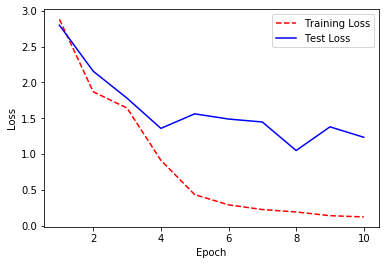

```python
#### model scores Metrics and graph
CNN1score = model.evaluate(test_images, y1_test)
print(CNN1score)
print()

CNN1training_loss = CNN1history.history['loss']
print('loss: ', round(np.mean(CNN1training_loss),2))
print()

CNN1training_acc = CNN1history.history['accuracy']
print('accuracy: ', round(np.mean(CNN1training_acc),2))
print()

CNN1test_loss = CNN1history.history['val_loss']
print('val_loss: ', round(np.mean(CNN1test_loss),2))
print()

CNN1test_acc = CNN1history.history['val_accuracy']
print('val_acc: ',round(np.mean(CNN1test_acc),2))
print()
print()
# Create count of the number of epochs
epoch_count = range(1, len(CNN1training_loss) + 1)

# Visualize loss history
plt.plot(epoch_count, CNN1training_loss, 'r--')
plt.plot(epoch_count, CNN1test_loss, 'b-')
plt.legend(['Training Loss', 'Test Loss'])
plt.xlabel('Epoch')
plt.ylabel('Loss')
plt.show()
```

It is quite obvious that the loss of the model on the test set seems to stabilize between 1.0 and 1.5, while for the training set los seems to get close to be nullified after the 7th iteration.

```python
#### Metrics on CNN image augmented test set
CNN1y_pred1 = model.predict(test_images,verbose=0, steps=None)
CNN1y_pred = np.argmax(CNN1y_pred1, axis=1)

CNN1accuracy = accuracy_score(y1_test, CNN1y_pred)
print("CNN1 accuracy: ", round(CNN1accuracy,3))

CNN1recall = recall_score(y1_test, CNN1y_pred , average="macro")
print("CNN1 recall: ", round(CNN1recall,3))

CNN1precision = precision_score(y1_test, CNN1y_pred , average="macro")
print("CNN1 precision: ", round(CNN1precision,3))

CNN1F1_score = f1_score(y1_test, CNN1y_pred , average="macro")
print("CNN1 F1-score: ", round(CNN1F1_score,3))

CNN1NNkapa = cohen_kappa_score(y1_test, CNN1y_pred)
print('kappa-score: ', round(CNN1NNkapa, 3))

CNN1NNMCC = matthews_corrcoef(y1_test, CNN1y_pred)
print('MCC: ', round(CNN1NNMCC,3))

print('Test loss:', round(CNN1score[0], 2))
```

```
CNN1 accuracy:  0.74
CNN1 recall:  0.597
CNN1 precision:  0.723
CNN1 F1-score:  0.603
kappa-score:  0.72
MCC:  0.724
```

### 4.2 CNN on second IMAGE AUGMENTED DATASET

What if instead of overdoing it with parameters an constant retraining of cnn, we instead focused on the actual data. What if a better augmented dataset for the same succesfull model would yield better results. Not only should we leave it at that but maybe increasing the learning rate could yield better results while at the same time prevent the danger of overfitting.

```python
### Creation of second image augmented dataset
targetBase3 = []
imgData3 = []
for path in listOfDirs:
    data_path = get_imlist(path)
    for i in data_path:
        files = glob.glob(i)
        x = pathlib.PurePath(i)
        y = x.parent.name
        targetBase3.append(y)
        targetBase3.append(y)
        targetBase3.append(y)
        targetBase3.append(y)
        targetBase3.append(y)
        targetBase3.append(y)
        for f1 in files:
            img = cv2.imread(f1, 0)
            img1 = cv2.resize(img, (100,100)) #image resize
            img2 = rotate(img1, 45) #image 45 degrees rotation
            img3 = util.invert(img1) #color inversion
            img4 = random_noise(img1)#add random noise
            img5 = median(img1) #pixel values are replaced with the median of neighboring pixels
            img6 = sobel_h(img1) #Find the horizontal edges of an image using the Sobel transform
            imgData3.append(img1)
            imgData3.append(img2)
            imgData3.append(img3)
            imgData3.append(img4)
            imgData3.append(img5)
            imgData3.append(img6)
```

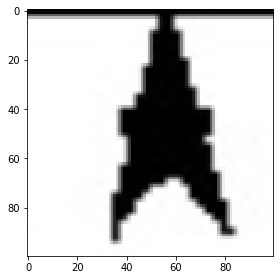

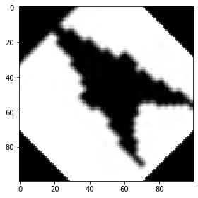

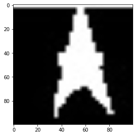

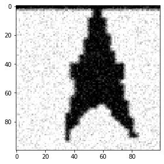

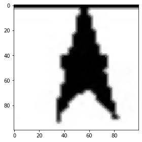

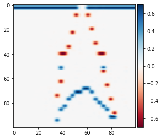

```python
io.imshow(imgData3[0])
io.show()
io.imshow(imgData3[1])
io.show()
io.imshow(imgData3[2])
io.show()
io.imshow(imgData3[3])
io.show()
io.imshow(imgData3[4])
io.show()
io.imshow(imgData3[5])
io.show()
```

Here we can clearly see the two new image transformations added upon the first image of the original image dataset.

```python
#### proof of image augmentation
print(len(imgData3))
print(imgData3[0].shape)
print()
print(len(targetBase3))
print(targetBase3[4000])
```

```
14592
(100, 100)

14592
DB&BPV
```

```python
#### repository of newly augmented images and their target
imgD3Copy = imgData3.copy()
```

```python
#### creation of unique indices for targets
import numpy as np
#print(targetBase2)
#T_base = np.asarray(targetBase)
#print(T_base)

tBaseCopy3 = targetBase3.copy()

tBaseCopy3, indices3 = np.unique(tBaseCopy3, return_inverse=True)

#print(tBaseCopy)
#print(tBaseCopy2[indices2])
#print(indices2)
#print(len(indices2))
#print(indices2[2])
#print(indices2[298])

# Create reshaped indices. inds will be the target/class from now on
indicesCP3 = indices3.copy()
print()
#print(indicesCP[0:240])
print()
inds3 =indicesCP3.reshape(-1,1)
#print(inds2[0:240])
```

```python
### Training/test set split
from sklearn.model_selection import train_test_split
np.random.seed(42)
X2_train, X2_test, y2_train, y2_test = train_test_split(imgD3Copy, indices3,
                                                    stratify=indices3,
                                                    test_size=0.25, random_state=40)
```

```python
X2_train = np.asarray(X2_train)
y2_train = np.asarray(y2_train)
X2_test = np.asarray(X2_test)
y2_test = np.asarray(y2_test)
```

```python
#### Reshaping of training/test set
X2_train = X2_train.reshape(10944, 100, 100,1)
X2_test = X2_test.reshape(3648, 100, 100,1)
```

```python
#### proof of reshaping
print("X2_train shape", X2_train.shape)
print("X2_train type", type(X2_train))
print()
print("y2_train shape", y2_train.shape)
print("y2_train type", type(y2_train))
print()
print("X2_test shape", X2_test.shape)
print(type(X2_test))
print()
print("y2_test shape", y2_test.shape)
print(type(y2_test))
```

```
X2_train shape (10944, 100, 100, 1)
X2_train type <class 'numpy.ndarray'>

y2_train shape (10944,)
y2_train type <class 'numpy.ndarray'>

X2_test shape (3648, 100, 100, 1)
<class 'numpy.ndarray'>

y2_test shape (3648,)
<class 'numpy.ndarray'>
```

```python
#### Normalize pixel values to be between 0 and 1
train_images2, test_images2 = X2_train / 255.0, X2_test / 255.0
```

```python
train_images2.shape
```

```
(10944, 100, 100, 1)
```

```python
#### model architecture
model = models.Sequential()
model.add(layers.Conv2D(32, (3, 3), activation='relu', input_shape=(100, 100, 1)))
model.add(Dropout(0.5))
model.add(layers.MaxPooling2D((2, 2)))
model.add(layers.Conv2D(64, (3, 3), activation='relu'))
model.add(Dropout(0.5))
model.add(layers.MaxPooling2D((2, 2)))
model.add(layers.Conv2D(64, (3, 3), activation='relu'))
model.add(Dropout(0.5))
model.add(layers.Flatten())
model.add(layers.Dense(64, activation='relu'))
model.add(layers.Dense(39))
model.add(Dense(y_train.shape[0], activation='softmax'))
adam = Adam(learning_rate=0.01, beta_1=0.9, beta_2=0.999, amsgrad=False)
```

```python
#### Summarising model
model.summary()
```

```
Model: "sequential_3"
_________________________________________________________________
Layer (type)                 Output Shape              Param #
=================================================================
conv2d_3 (Conv2D)            (None, 98, 98, 32)        320
_________________________________________________________________
dropout_9 (Dropout)          (None, 98, 98, 32)        0
_________________________________________________________________
max_pooling2d_2 (MaxPooling2 (None, 49, 49, 32)        0
_________________________________________________________________
conv2d_4 (Conv2D)            (None, 47, 47, 64)        18496
_________________________________________________________________
dropout_10 (Dropout)         (None, 47, 47, 64)        0
_________________________________________________________________
max_pooling2d_3 (MaxPooling2 (None, 23, 23, 64)        0
_________________________________________________________________
conv2d_5 (Conv2D)            (None, 21, 21, 64)        36928
_________________________________________________________________
dropout_11 (Dropout)         (None, 21, 21, 64)        0
_________________________________________________________________
flatten_1 (Flatten)          (None, 28224)             0
_________________________________________________________________
dense_11 (Dense)             (None, 64)                1806400
_________________________________________________________________
dense_12 (Dense)             (None, 39)                2535
_________________________________________________________________
dense_13 (Dense)             (None, 7296)              291840
=================================================================
Total params: 2,156,519
Trainable params: 2,156,519
Non-trainable params: 0
_________________________________________________________________
```

```python
model.compile(optimizer='adam',
              loss=tf.keras.losses.SparseCategoricalCrossentropy(),
              metrics=['accuracy'])
```

```python
#### Training model
CNN2history = model.fit(train_images2, y2_train, validation_data=(test_images2, y2_test), epochs=10)
```

```
Train on 10944 samples, validate on 3648 samples
```

```python
#### get last instance of cross validation
import math

print('val_loss; ', round(np.mean(test_loss),2))
CNN2test_acc = CNN2history.history['val_accuracy']
print('val_acc: ',round(np.mean(CNN2test_acc),3))
```

[output not shown]

```
[1.5860049855290799, 0.56578946]

loss:  1.66

accuracy:  0.54

val_loss:  1.81

val_acc:  0.55
```

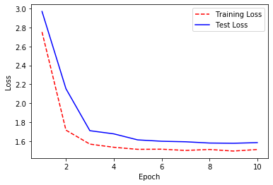

```python
#### Metrics and graph
CNN2score = model.evaluate(test_images2, y2_test)
print(CNN2score)
print()

CNN2training_loss = CNN2history.history['loss']
print('loss: ', round(np.mean(CNN2training_loss),2))
print()

CNN2training_acc = CNN2history.history['accuracy']
print('accuracy: ', round(np.mean(CNN2training_acc),2))
print()

CNN2test_loss = CNN2history.history['val_loss']
print('val_loss: ', round(np.mean(CNN2test_loss),2))
print()

CNN2test_acc = CNN2history.history['val_accuracy']
print('val_acc: ',round(np.mean(CNN2test_acc),2))
print()
print()
# Create count of the number of epochs
epoch_count = range(1, len(CNN2training_loss) + 1)

# Visualize loss history
plt.plot(epoch_count, CNN2training_loss, 'r--')
plt.plot(epoch_count, CNN2test_loss, 'b-')
plt.legend(['Training Loss', 'Test Loss'])
plt.xlabel('Epoch')
plt.ylabel('Loss')
plt.show()
```

It is quite obvious that the loss of the model on the test set seems to stabilize at 1.6 after the 5th iteration, while for the training set loss seems to get below 1.6 after the 3rd iteration. Also, both loss depictions follow the same very stable trend, which is a sign of good performance.

```python
#### Metrics on CNN image augmented test set
CNN2y_pred1 = model.predict(test_images2,verbose=0, steps=None)
CNN2y_pred = np.argmax(CNN2y_pred1, axis=1)

CNN2accuracy = accuracy_score(y2_test, CNN2y_pred)
print("CNN2 accuracy: ", round(CNN2accuracy,3))

CNN2recall = recall_score(y2_test, CNN2y_pred , average="macro")
print("CNN2 recall: ", round(CNN2recall,3))

CNN2precision = precision_score(y2_test, CNN2y_pred , average="macro")
print("CNN2 precision: ", round(CNN2precision,3))

CNN2F1_score = f1_score(y2_test, CNN2y_pred , average="macro")
print("CNN2 F1-score: ", round(CNN2F1_score,3))

CNN2NNkapa = cohen_kappa_score(y2_test, CNN2y_pred)
print('kappa-score: ', round(CNN2NNkapa, 3))

CNN2NNMCC = matthews_corrcoef(y2_test, CNN2y_pred)
print('MCC: ', round(CNN2NNMCC,3))

print('Test loss:', round(score[0], 2))
```

```
CNN2 accuracy:  0.672
CNN2 recall:  0.589
CNN2 precision:  0.811
CNN2 F1-score:  0.631
kappa-score:  0.648
MCC:  0.663
```

## 5. RESULTS-DISCUSSION

A table containing results for each model has been created. These results are the metrics for each model when model is applied on the test set, because this is what matters-how the model performs on unseen data.

```python
import pandas as pd
```

```python
Classification_Validation_Method = ['SVM', 'SVM CV', 'RF', 'RF CV','DesT', 'DesT CV', 'SVM', 'SVM CV', 'RF', 'RF CV', 'DesT', 'DesT CV','NN','NN val', 'NN', 'NN val', 'CNN1', 'CNN1 val', 'CNN2', 'CNN2 val', 'SVM','SVM CV', 'RF', 'RF CV', 'DesT', 'DesT CV','SVM','SVM CV', 'RF', 'RF CV', 'DesT', 'DesT CV', 'NN', 'NN val', 'NN', 'NN val','SVM', 'SVM CV', 'RF', 'RF CV','DesT', 'DesT CV','SVM', 'SVM CV', 'RF', 'RF CV','DesT', 'DesT CV', 'NN', 'NN val','NN', 'NN val']
```

```python
DataSet=['HOG augmented', 'HOG augmented', 'HOG augmented', 'HOG augmented', 'HOG augmented',  'HOG augmented', 'PCA augmented', 'PCA augmented', 'PCA augmented', 'PCA augmented', 'PCA augmented', 'PCA augmented','HOG augmented','HOG augmented', 'PCA augmented', 'PCA augmented','IMAGE augmented','IMAGE augmented','IMAGE augmented','IMAGE augmented','dec_kmean_HOG', 'dec_kmean_HOG','dec_kmean_HOG','dec_kmean_HOG','dec_kmean_HOG','dec_kmean_HOG', 'dec_AGG_HOG', 'dec_AGG_HOG', 'dec_AGG_HOG', 'dec_AGG_HOG', 'dec_AGG_HOG', 'dec_AGG_HOG', 'dec_kmean_HOG','dec_kmean_HOG','dec_AGG_HOG', 'dec_AGG_HOG', 'dec_kmean_PCA','dec_kmean_PCA','dec_kmean_PCA','dec_kmean_PCA','dec_kmean_PCA','dec_kmean_PCA','dec_AGG_PCA','dec_AGG_PCA','dec_AGG_PCA','dec_AGG_PCA','dec_AGG_PCA','dec_AGG_PCA', 'dec_kmean_PCA', 'dec_kmean_PCA','dec_AGG_PCA','dec_AGG_PCA']
```

```python
Accuracy =[0.811, 0.75, 0.989, 0.98, 0.594, 0.63, 0.157,0.150, 0.86, 0.85, 0.86, 0.85, 0.995, 0.98, 0.447, 0.39, 0.74, 0.65, 0.672, 0.55, 0.518, 0.66, 0.976, 0.97, 0.703, 0.77, 0.493, 0.46, 0.988, 0.99, 0.535, 0.57, 0.98, 0.95, 0.988, 0.95,0.212,0.15,0.805,0.81,0.805,0.810, 0.363, 0.19, 0.812, 0.810, 0.811, 0.810, 0.437, 0.34, 0.493, 0.37]
Recall= [0.815, 0.75, 0.989, 0.98, 0.595, 0.63, 0.158, 0.150, 0.86, 0.85, 0.86, 0.85, 0.996, 'Null', 0.448, 'Null', 0.597, 'Null', 0.589, 'Null', 0.523, 0.67, 0.976, 0.97, 0.703, 0.77, 0.517, 'Null', 0.988, 0.99, 0.537, 0.57, 0.98, 'Null', 0.987, 'Null', 0.215, 0.15, 0.806, 0.810, 0.806, 0.810, 0.363, 0.15, 0.812, 0.810, 0.811, 0.810, 0.438, 'Null',0.493, 'Null']
Precision = [0.891, 0.79, 0.989, 0.98, 0.798, 0.82, 0.542, 0.09, 0.89, 0.88, 0.89, 0.88, 0.996, 'Null', 0.453, 'Null', 0.723, 'Null', 0.811, 'Null', 0.889, 0.63, 0.977, 0.97, 0.911, 0.9, 0.842, 'Null', 0.989, 0.99, 0.969, 0.67, 0.981, 'Null', 0.989, 'Null', 0.668, 0.07, 0.825, 0.830, 0.857, 0.830, 0.615, 0.09, 0.91, 0.810, 0.909, 0.810, 0.553, 'Null', 0.676, 'Null' ]
F1_score =[0.779, 0.72, 0.989, 0.98, 0.616, 0.66, 0.092, 0.08, 0.86, 0.85, 0.86, 0.85, 0.996, 'Null', 0.385, 'Null', 0.603, 'Null', 0.631, 'Null', 0.483, 0.61, 0.976, 0.97, 0.756, 0.81, 0.413, 'Null', 0.987, 0.99, 0.548, 0.58, 0.979, 'Null', 0.987, 'Null', 0.12, 0.08, 0.803, 0.8, 0.803, 0.8, 0.266, 0.1, 0.796, 0.8, 0.794, 0.8, 0.371, 'Null', 0.425, 'Null']
Loss=['Null','Null','Null','Null', 'Null', 'Null', 'Null','Null','Null','Null', 'Null', 'Null', 0.05, 0.1, 1.72, 2.01, 1.23, 1.63, 1.59, 1.81, 'Null', 'Null', 'Null', 'Null', 'Null', 'Null', 'Null', 'Null', 'Null', 'Null', 'Null', 'Null', 0.16, 0.25, 0.07, 0.26,'Null','Null','Null','Null', 'Null', 'Null','Null','Null','Null','Null', 'Null', 'Null', 1.85, 2.3, 1.66, 2.3]
MCC=[0.81,'Null',0.989, 'Null',0.630, 'Null', 0.144, 'Null', 0.856, 'Null', 0.858, 'Null',0.995, 'Null',0.437, 'Null', 0.724, 'Null', 0.663, 'Null', 0.528, 'Null', 0.976, 'Null', 0.723, 'Null', 0.494, 'Null', 0.988, 'Null', 0.589, 'Null', 0.98, 'Null', 0.988, 'Null', 0.205, 'Null', 0.804, 'Null',0.803, 'Null', 0.362, 'Null', 0.814, 'Null', 0.812, 'Null', 0.431, 'Null', 0.492, 'Null']
kappa=[0.806,'Null', 0.989, 'Null',0.584, 'Null', 0.135, 'Null', 0.855, 'Null', 0.857, 'Null',0.995, 'Null', 0.433, 'Null', 0.720, 'Null', 0.648, 'Null', 0.511, 'Null', 0.976, 'Null', 0.699, 'Null', 0.491, 'Null', 0.988, 'Null', 0.532, 'Null', 0.979, 'Null', 0.988, 'Null', 0.2, 'Null',0.802, 'Null', 0.802,'Null', 0.36, 'Null',0.811, 'Null',0.811,'Null', 0.428, 'Null', 0.49, 'Null' ]
```

```python
list_of_tuples = list(zip(DataSet, Classification_Validation_Method ,Accuracy,Recall, Precision, F1_score,Loss, MCC, kappa))
```

```python
import pandas as pd
Lastdf = pd.DataFrame(list_of_tuples, columns = ['DataSet','Classification_Validation_Method', 'Accuracy','Recall','Precision','F1_score','Loss', 'MCC', 'kappa'])
```

```python
Lastdf
```

|  | DataSet | Classification_Validation_Method | Accuracy | Recall | Precision | F1_score | Loss | MCC | kappa |
| --- | --- | --- | --- | --- | --- | --- | --- | --- | --- |
| 0 | HOG augmented | SVM | 0.811 | 0.815 | 0.891 | 0.779 | Null | 0.81 | 0.806 |
| 1 | HOG augmented | SVM CV | 0.750 | 0.75 | 0.79 | 0.72 | Null | Null | Null |
| 2 | HOG augmented | RF | 0.989 | 0.989 | 0.989 | 0.989 | Null | 0.989 | 0.989 |
| 3 | HOG augmented | RF CV | 0.980 | 0.98 | 0.98 | 0.98 | Null | Null | Null |
| 4 | HOG augmented | DesT | 0.594 | 0.595 | 0.798 | 0.616 | Null | 0.63 | 0.584 |
| 5 | HOG augmented | DesT CV | 0.630 | 0.63 | 0.82 | 0.66 | Null | Null | Null |
| 6 | PCA augmented | SVM | 0.157 | 0.158 | 0.542 | 0.092 | Null | 0.144 | 0.135 |
| 7 | PCA augmented | SVM CV | 0.150 | 0.15 | 0.09 | 0.08 | Null | Null | Null |
| 8 | PCA augmented | RF | 0.860 | 0.86 | 0.89 | 0.86 | Null | 0.856 | 0.855 |
| 9 | PCA augmented | RF CV | 0.850 | 0.85 | 0.88 | 0.85 | Null | Null | Null |
| 10 | PCA augmented | DesT | 0.860 | 0.86 | 0.89 | 0.86 | Null | 0.858 | 0.857 |
| 11 | PCA augmented | DesT CV | 0.850 | 0.85 | 0.88 | 0.85 | Null | Null | Null |
| 12 | HOG augmented | NN | 0.995 | 0.996 | 0.996 | 0.996 | 0.05 | 0.995 | 0.995 |
| 13 | HOG augmented | NN val | 0.980 | Null | Null | Null | 0.1 | Null | Null |
| 14 | PCA augmented | NN | 0.447 | 0.448 | 0.453 | 0.385 | 1.72 | 0.437 | 0.433 |
| 15 | PCA augmented | NN val | 0.390 | Null | Null | Null | 2.01 | Null | Null |
| 16 | IMAGE augmented | CNN1 | 0.740 | 0.597 | 0.723 | 0.603 | 1.23 | 0.724 | 0.72 |
| 17 | IMAGE augmented | CNN1 val | 0.650 | Null | Null | Null | 1.63 | Null | Null |
| 18 | IMAGE augmented | CNN2 | 0.672 | 0.589 | 0.811 | 0.631 | 1.59 | 0.663 | 0.648 |
| 19 | IMAGE augmented | CNN2 val | 0.550 | Null | Null | Null | 1.81 | Null | Null |
| 20 | dec_kmean_HOG | SVM | 0.518 | 0.523 | 0.889 | 0.483 | Null | 0.528 | 0.511 |
| 21 | dec_kmean_HOG | SVM CV | 0.660 | 0.67 | 0.63 | 0.61 | Null | Null | Null |
| 22 | dec_kmean_HOG | RF | 0.976 | 0.976 | 0.977 | 0.976 | Null | 0.976 | 0.976 |
| 23 | dec_kmean_HOG | RF CV | 0.970 | 0.97 | 0.97 | 0.97 | Null | Null | Null |
| 24 | dec_kmean_HOG | DesT | 0.703 | 0.703 | 0.911 | 0.756 | Null | 0.723 | 0.699 |
| 25 | dec_kmean_HOG | DesT CV | 0.770 | 0.77 | 0.9 | 0.81 | Null | Null | Null |
| 26 | dec_AGG_HOG | SVM | 0.493 | 0.517 | 0.842 | 0.413 | Null | 0.494 | 0.491 |
| 27 | dec_AGG_HOG | SVM CV | 0.460 | Null | Null | Null | Null | Null | Null |
| 28 | dec_AGG_HOG | RF | 0.988 | 0.988 | 0.989 | 0.987 | Null | 0.988 | 0.988 |
| 29 | dec_AGG_HOG | RF CV | 0.990 | 0.99 | 0.99 | 0.99 | Null | Null | Null |
| 30 | dec_AGG_HOG | DesT | 0.535 | 0.537 | 0.969 | 0.548 | Null | 0.589 | 0.532 |
| 31 | dec_AGG_HOG | DesT CV | 0.570 | 0.57 | 0.67 | 0.58 | Null | Null | Null |
| 32 | dec_kmean_HOG | NN | 0.980 | 0.98 | 0.981 | 0.979 | 0.16 | 0.98 | 0.979 |
| 33 | dec_kmean_HOG | NN val | 0.950 | Null | Null | Null | 0.25 | Null | Null |
| 34 | dec_AGG_HOG | NN | 0.988 | 0.987 | 0.989 | 0.987 | 0.07 | 0.988 | 0.988 |
| 35 | dec_AGG_HOG | NN val | 0.950 | Null | Null | Null | 0.26 | Null | Null |
| 36 | dec_kmean_PCA | SVM | 0.212 | 0.215 | 0.668 | 0.12 | Null | 0.205 | 0.2 |
| 37 | dec_kmean_PCA | SVM CV | 0.150 | 0.15 | 0.07 | 0.08 | Null | Null | Null |
| 38 | dec_kmean_PCA | RF | 0.805 | 0.806 | 0.825 | 0.803 | Null | 0.804 | 0.802 |
| 39 | dec_kmean_PCA | RF CV | 0.810 | 0.81 | 0.83 | 0.8 | Null | Null | Null |
| 40 | dec_kmean_PCA | DesT | 0.805 | 0.806 | 0.857 | 0.803 | Null | 0.803 | 0.802 |
| 41 | dec_kmean_PCA | DesT CV | 0.810 | 0.81 | 0.83 | 0.8 | Null | Null | Null |
| 42 | dec_AGG_PCA | SVM | 0.363 | 0.363 | 0.615 | 0.266 | Null | 0.362 | 0.36 |
| 43 | dec_AGG_PCA | SVM CV | 0.190 | 0.15 | 0.09 | 0.1 | Null | Null | Null |
| 44 | dec_AGG_PCA | RF | 0.812 | 0.812 | 0.91 | 0.796 | Null | 0.814 | 0.811 |
| 45 | dec_AGG_PCA | RF CV | 0.810 | 0.81 | 0.81 | 0.8 | Null | Null | Null |
| 46 | dec_AGG_PCA | DesT | 0.811 | 0.811 | 0.909 | 0.794 | Null | 0.812 | 0.811 |
| 47 | dec_AGG_PCA | DesT CV | 0.810 | 0.81 | 0.81 | 0.8 | Null | Null | Null |
| 48 | dec_kmean_PCA | NN | 0.437 | 0.438 | 0.553 | 0.371 | 1.85 | 0.431 | 0.428 |
| 49 | dec_kmean_PCA | NN val | 0.340 | Null | Null | Null | 2.3 | Null | Null |
| 50 | dec_AGG_PCA | NN | 0.493 | 0.493 | 0.676 | 0.425 | 1.66 | 0.492 | 0.49 |
| 51 | dec_AGG_PCA | NN val | 0.370 | Null | Null | Null | 2.3 | Null | Null |

```python
import seaborn as sns
import matplotlib.pyplot as plt
%matplotlib inline
sns.set(style="ticks", color_codes=True)
```

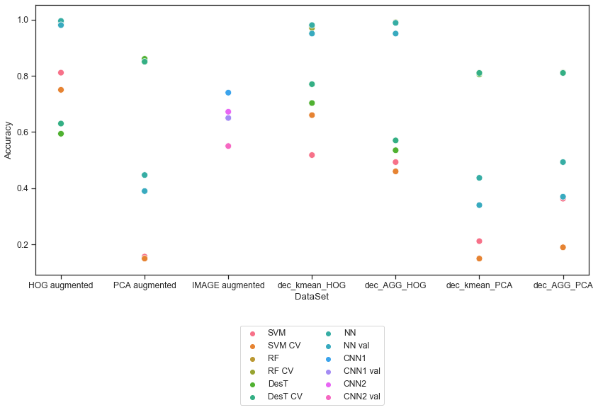

```python
sns.set_context("notebook", font_scale=1.1)
fig, ax = plt.subplots(figsize = (14,7))
finplot = sns.scatterplot(x="DataSet", y="Accuracy", hue="Classification_Validation_Method", data=Lastdf,
                      s=80,legend = 'brief',ax=ax)
handles, labels = ax.get_legend_handles_labels()

ax.legend(handles=handles[1:], labels=labels[1:], loc=8,
          ncol=2, bbox_to_anchor=[0.5,-0.5,0,0])
plt.show()
```

Above we can see the depicted accuracy of each classifier on each dataset

#### HOG augmented dataset

When SVM model was applied the model achieved 81.1% accuracy, 81.5% recall, 89.1% precision and 77.9% F1-score. When cross-validation was applied 75% accuracy, 75% recall, 79% precision and 72% F1-score were achieved. Both statistical significance evaluators scored very high with MCC at 0.81 and kappa at 0.806.

When Random Forest model was used, it gave back 98.9% accuracy, 98.9%recall, 98.9% precision and 98.9% F1-score. When cross-validation was applied 98% accuracy, 98% recall, 98% precision and 98% F1-score was achieved. Both statistical significance evaluators scored very high with MCC at 0.989 and kappa at 0.989.

When Decision Tree model was used, 59.4% accuracy, 59.5% recall, 79.8% precision and 61.6% F1-score were achieved. When cross validation was applied 63% accuracy, 63% recall, 82% precision and 66% F1-score were achieved. Both statistical significance evaluators scored moderate with MCC at 0.63 and kappa at 0.584.

Comparing the three algorithms, the worst performing one is decision trees. The one showing best performance is random forest though we always need to keep in mind that such high metrics may be a sign of overfitting and may not be fully trusted. So, one may have to side with SVM as the best classifier on HOG augmented dataset even though it may not have the best metrics.

#### PCA augmented dataset

For PCA augmented dataset the same metrics were used to evaluate the SVM , random forest and decision trees models. When SVM model was used, it gave back 15.7% accuracy, 15.8%recall, 54.2% precision and 9.2% F1-score. When cross-validation was applied 15% accuracy, 15% recall, 9% precision and 8% F1-score was achieved. Both statistical significance evaluators score very low to unacceptable levels witn MCC at 0.144 and kappa at 0.135.

When random forest model was used, it gave back 86% accuracy, 86%recall, 89% precision and 86% F1-score. When cross-validation was applied 85% accuracy, 85% recall, 88% precision and 85% F1-score was achieved. Both statistical significance evaluators score really high with MCC at 0.856 and kappa at 0.855. This means that the model produced gives results over the test set that are statistically important.

When decision tree model was used, 86% accuracy, 86% recall, 89% precision and 86% F1-score were achieved. When cross validation was applied 85% accuracy, 85% recall, 88% precision and 85% F1-score were achieved. Both statistical significance evaluators score really high with MCC at 0.858 and kappa at 0.857. This means that the model produced gives results over the test set that are statistically important.

Comparing the three algorithms we see that SVM is not to be trusted as it scores really low in all metrics and results that bare no statistical significance. Random Forest and Decision Trees on the other hand produce similarly robust models with statistically significant results that can be trusted to not overfit the data Generally, it is a common strategy to do a PCA on the dataset-even as a feature extraction technique-and then apply decision trees. We see here that this strategy does give back really good results and not only for decision trees, but for random forest too. Perhaps this is to be expected given that random forest is based on decision trees.

#### NN

The best model for NN for **HOG augmented dataset** was found to be the one with activation function “tanh”- ran for 200 epochs, lr=0.1, decay=1e-2, momentum=0.9, nesterov=True, two inner layers at 128 neurons. Increasing the epochs does not provide better results. Decreasing the learning rate causes a drop in accuracy. Same goes for decay. Accuracy was at 99.5%, recall at 99.6%, precision at 99.6%, F1-score at 99.6% with loss at 0.05. Statistical significance evaluators MCC and kappa also score at the highest level at 0.995 both. This shows that this model distinguishes between different targets perfectly over the entire test set and given that validation accuracy is at 98% with validation loss at 0.1 this conclusion can be applied for the entire dataset. The NN seems to outperform for this dataset both Random Forest and Decision trees classifiers but we have to keep in mind that it takes longer to train and test it and there is also the chance of overfitting the data when such high accuracy is obtained.

Another point that can be made regarding NNs, is that, more layers with medium number of neurons gives better results in all metrics used and time needed to run the model in contrast with less layers than more neurons per layer

The best model for NN for **PCA augmented dataset** was found to be the one with activation function “tanh” ran for 500 epochs, lr=0.01, decay=1e-4-2, layers of 128 neurons. Increasing the epochs does not provide better results. Decreasing the learning rate causes a drop in accuracy. Same goes for decay. Accuracy was at 44.7%, recall at 44.8%, precision at 45.3%, F1-score at 38.5% with los at 1.72. It is quite obvious that the NN does not work well with this dataset yielding very low metrics Furthermore, both statistical significance evaluators score really low with MCC at 0.437 and kappa at 0.433 which means that results produced are not to be trusted and only a small percent of the dataset can be reliably classified. Perhaps it is hard for the NN to understand what principal components are and thus learn from them. PCA makes no guarantees that the principal components make demarcation between different classes easier. This is because the principal axes computed are axes that merely try to maximize the energy of projection across all images, agnostic to image class. In contrast, actual images - whether faithfully reconstructed or not, still maintain some aspect of spatial differences that can go - or should go - towards making classification possible.

#### CNN

For the **first augmented image dataset** the best model was found to be with “Adam” optimizer and relu as activation function. For CNN all models were trained at 10 epochs. The CNN on the augmented imbalanced image dataset yielded 74% accuracy, 59.7% recall, 72.3% precision, 60.3% F1-score with loss at 1.23. Statistical significance is moderate with MCC at 0.724 and kappa at 0.72. This means that the model can be trusted to classify unseen data with adequately trustworthy results, though one has to bare in mind that given that the dataset is imbalanced F1-score plays an important role and here it scores relatively low and validation accuracy is 10% lower than accuracy on the test set alone with validation los at 1.63.

For the **second augmented image dataset** the same model as above was used. The CNN on the augmented imbalanced image dataset yielded 67.2% accuracy, 58.9% recall, 81.1% precision, 63.1% F1-score with loss at 1.59. Statistical significance evaluators score moderately with MCC at 0.663 and kappa at 0.648, while evaluation accuracy is at 55% and evaluation loss at 1.81. The CNN does not do that much of a good job here to produce a robust model though it is a model that probably can be trusted given that loss over the test set follows the same trend as validation loss. It is important to notice here that both datasets used in CNN building were imbalanced. This means that F1-score plays a more important role than precision or recall alone, taking into account both of them. Generally, a F1-score close and above 80% is considered acceptable. It is quite interesting to notice that by adding just two different, yet more demanding, image transformations as well as greatly expanding the number of images compared to the first dataset used, accuracy drops by 7%, but the rest of the metrics remain pretty much the same with precision even rising by 9%. Maybe this shows the power of CNN to adjust to different occasions.

#### Decomposed k-means HOG feature augmented dataset

When SVM model was applied the model achieved 51.8% accuracy, 52.3% recall, 88.9% precision and 48.3% F1-score. When cross-validation was applied 66% accuracy, 67% recall, 63% precision and 61% F1-score were achieved. Both statistical significance evaluators scored moderate with MCC at 0.528 and kappa at 0.511.

When Random Forest model was used, it gave back 97.6% accuracy, 97.6%recall, 97.7% precision and 97.6% F1-score. When cross-validation was applied 97% accuracy, 97% recall, 97% precision and 97% F1-score was achieved. Both statistical significance evaluators scored very high with MCC at 0.976 and kappa at 0.976.

When Decision Tree model was used, 70.3% accuracy, 70.3% recall, 91.1% precision and 75.6% F1-score were achieved. When cross validation was applied 77% accuracy, 77% recall, 90% precision and 81% F1-score were achieved. Both statistical significance evaluators scored well with MCC at 0.723 and kappa at 0.699.

Comparing these three classification algorithms we can clearly see that SVM performs the worse than all. Random Forest achieves the highest scores for all metrics and statistical significanve factors, with excellent agreement between truw and predicted results over the test set, backed by high validation scores. When such high scores are obtained one has to always keep in mind the chance of overfitting, and it along with random forest one may also use Decision Trees which scores well too for the same metrics.

#### Decomposed agglomerative clustering HOG feature augmented dataset

When SVM model was applied the model achieved 49.3% accuracy, 51.7% recall, 84.2% precision and 41.3% F1-score. When cross-validation was applied 46% accuracy. Both statistical significance evaluators scored moderate with MCC at 0.494 and kappa at 0.491.

When Decision Tree model was used, 53.5% accuracy, 53.7% recall, 96.9% precision and 54.8% F1-score were achieved. When cross validation was applied 57% accuracy, 57% recall, 67% precision and 58% F1-score were achieved. Both statistical significance evaluators scored moderate with MCC at 0.589 and kappa at 0.532.

Comparing these three classification algorithms the superiority of Random Forest is unequivocal. Random Forest achieves the highest scores for all metrics and statistical significanve factors, with excellent agreement between truw and predicted results over the test set, backed by high validation scores. When such high scores are obtained one has to always keep in mind the chance of overfitting, but here there is no alternative since for the other two algorithms even the agreement between true and predicted results over the test set is very low.

#### NNs on HOG decomposed datasets

Accuracy was at 98%, recall at 98%, precision at 98.1%, F1-score at 97.9% with loss at 0.16. Statistical significance evaluators MCC and kappa also score at the highest level at 0.98 both. This shows that this model distinguishes between different targets perfectly over the entire test set and given that validation accuracy is at 95% with validation loss at 0.25 this conclusion can be applied for the entire dataset. The NN seems to outperform for this dataset Decision trees classifier, but does equally well with Random Forest.

If we were to compare how the classifiers perform between the k-means decomposed and not decomposed dataset of HOG extracted features, baring in mind the differences in datasets, it is quite interesting to notice that when the number of classes rises, almost doubles for this occasion, the SVM not only needs more time than the NN to run, but its robustness falls significantly. Decision Trees seems to do a better job, while Random Forest and NNs face absoloutely no challenge in keeping their metrics excellent.

If we were to compare how the classifiers perform between the agglomerative clustering decomposed and not decomposed dataset of HOG extracted features, baring in mind the differences in datasets, it is quite interesting to notice that when the number of classes rises, almost quadruples for this occasion, the SVM not only needs more time than the NN to run, but its robustness falls significantly. Decision Trees does not seem to do a better job. On the other hand Random Forest and NNs face absoloutely no challenge in keeping their metrics excellent. Perhaps this is a sign that NNs work better the more structured information they are fed, while SVM faces problems in building many more hyper-planes for the classes to be separated correctly.

#### Decomposed k-means PCA feature augmented dataset

When SVM model was applied the model achieved 21.2% accuracy, 21.5% recall, 66.8% precision and 12% F1-score. When cross-validation was applied 15% accuracy, 15% recall, 7% precision and 8% F1-score were achieved. Both statistical significance evaluators scored at unacceptable levels with MCC at 0.205 and kappa at 0.2.

When Random Forest model was used, 80.5% accuracy, 80.6% recall, 82.5% precision and 80.3% F1-score were achieved. When cross validation was applied 81% accuracy, 81% recall, 83% precision and 80.3% F1-score were achieved. Both statistical significance evaluators scored really well with MCC at 0.804 and kappa at 0.802.

When Decision Tree model was used, it gave back 80.5% accuracy, 80.6%recall, 85.7% precision and 80.3 F1-score. When cross-validation was applied 81% accuracy, 81% recall, 83% precision and 80.3% F1-score was achieved. Both statistical significance evaluators scored very high with MCC at 0.803 and kappa at 0.802.

Comparing these three classification algorithms we can clearly see that SVM performs worse than all. Random Forest and Decision Tree achieve the same scores for all metrics and statistical significanve factors, with Decision Tree having a bit better precision. We also see excellent agreement between true and predicted results over the test set, backed by high validation scores for both classifiers. Baring in mind that Random Forest works through majority vote of many Decision Trees created one may have to side with Random Forest for future use in case they had to chose.

#### Decomposed agglomerative clustering on PCA feature augmented dataset

When SVM model was applied the model achieved 36.3% accuracy, 36.3% recall, 61.5% precision and 26.6% F1-score. When cross-validation was applied 19% accuracy, 15% recall, 9% precision and 10% F1-score was achieved. Both statistical significance evaluators scored at unacceptable levels with MCC at 0.362 and kappa at 0.36.

When Random Forest model was used, it gave back 81.2% accuracy, 81.2%recall, 91% precision and 79.6% F1-score. When cross-validation was applied 81% accuracy, 81% recall, 81% precision and 80% F1-score was achieved. Both statistical significance evaluators scored high with MCC at 0.814 and kappa at 0.811.

For agglomerative clustering being used as the decomposition method we see that the results follow the same pattern as for k-means decompostion method. Specifically, SVM classifier does a really poor job regareding all metrics and with very low agreement between true and predicted results. On the other hand, Random Forest and Decision Tree classifiers work again in basically the same manner producing robust models with high scores on all metrics and good agreement between true and predicted results. Following the same line of though one may want to chose Random Forest as the classifier to go with given that it is based on a majority vote from multiple decision trees created.

#### NNs on PCA decomposed datasets

Regarding the application of NNs on the **k-means decomposed PCA feature augmented dataset** the model used was the the same as for the HOG decomposed dataset.

Accuracy was at 43.7%, recall at 43.8%, precision at 55.3%, F1-score at 37.1% with loss at 1.85. Statistical significance evaluators MCC and kappa also score at low level at 0.431 and 0.428, respectively. This shows that this model does a poor job in distinguishing between different targets over the entire test set and given that validation accuracy is at 34%% with validation loss at 2.3% the NN seems to be the worst machine learning classifier along with SVM.

Accuracy was at 49.3%, recall at 49.3%, precision at 67.6%, F1-score at 42.5% with loss at 1.66. Statistical significance evaluators MCC and kappa also score at low level at 0.49 both. This shows that this model does a poor job in distinguishing between different targets over the entire test set and given that validation accuracy is at 37% with validation loss at 2.3% the NN seems to be the worst machine learning classifier along with SVM.

If we were to compare how the classifiers perform between the k-means or agglomerative clustering decomposed and not decomposed dataset of PCA extracted features, baring in mind the differences in datasets, it is quite interesting to notice that when the number of classes rises, almost quadruples for one occasion, Random Forest and Decision Trees seems to keep working very well, while NNs regardless of the dataset being decomposed or not or the type of the decomposition, they keep on having a problem in learning from a PCA features dataset.

## 6. FUTURE CHALLENGES

It would be quite interesting to see how the learning ability of NNs could increase regarding a PCA dataset. Perhaps, making the model learn on just the first 2 or 3 principal components, that is the ones that contain most of the initial information of the original dataset, could yield better results.

Another quite interesting topic to research would be how different kind of augmentations influence a model already known to perform well. Here one such case was investigated regarding the CNN and one using the NN on one of the decomposed PCA datasets. Such a direction could be followed with NNs or even with the rest of machine learning algorithms used. The size of the augmented dataset may also play a role in how a previously successful model will perform.

## 7. COMMENTS

1. Some code chunks have been deprived of their output for mere aesthetics of the produced document, though proof of their result is provided.
2. Only the metrics of the classifiers on the test set is being reported here, because that is what is considered important and presenting the training set results of the classifier would not offer much help in the solutions this project is aimed at providing
3. In the notebook submitted for the due date of PART1 Harris Corner feature extraction was also included and it was succesfully implemented. However, I chose to exclude it from this final submit as I thought it would be more constructive to focus on other parts of the coursework such as data and image augmentation, class decomposition and implementing as many classifiers as possible, while testing as many NN and CNN models as possible to find the best hyperparameter tuning.
4. In the case of applying the SVM algorithm on the agglomerative clustering deomposed HOG feature extracted dataset no validation metrics are shown on the final table except for validation accuracy. This has to do with my computer not possesing the adequate processing power to produce the results, though the code provided is correct.

```
                                         THE END
```